# PRANGYA PROJECT

### PRANGYA PARIMITA PRIYADARSINI PATRA

Mail Id: prangyapatra76@gmail.com

### Wholesale Customers Dataset Analysis

Given Details

1) FRESH: annual spending (m.u.) on fresh products (Continuous); 2) MILK: annual spending (m.u.) on milk products (Continuous); 3) GROCERY: annual spending (m.u.)on grocery products (Continuous); 4) FROZEN: annual spending (m.u.)on frozen products (Continuous) 5) DETERGENTS_PAPER: annual spending (m.u.) on detergents and paper products (Continuous) 6) DELICATESSEN: annual spending (m.u.)on and delicatessen products (Continuous); 7) CHANNEL: customers’ Channel - Horeca (Hotel/Restaurant/Café) or Retail channel (Nominal) 8) REGION: customers’ Region – Lisnon, Oporto or Other (Nominal) Descriptive Statistics:

```
(Minimum, Maximum, Mean, Std. Deviation)
```

FRESH ( 3, 112151, 12000.30, 12647.329) MILK (55, 73498, 5796.27, 7380.377) GROCERY (3, 92780, 7951.28, 9503.163) FROZEN (25, 60869, 3071.93, 4854.673) DETERGENTS_PAPER (3, 40827, 2881.49, 4767.854) DELICATESSEN (3, 47943, 1524.87, 2820.106)

REGION Frequency Lisbon 77 Oporto 47 Other Region 316 Total 440

CHANNEL Frequency Horeca 298 Retail 142 Total 440

### 1. Write a code to check Numpy, Matplotlib, Scipy, Panda, Scikit-learn, TensorFlow, Keras, PyTorch to check these are installed or not.

```python
import importlib

libs = ['numpy', 'matplotlib', 'scipy', 'pandas', 'sklearn', 'tensorflow', 'keras', 'torch']

for lib in libs:
    try:
        importlib.import_module(lib)
        print(f"{lib} is installed")
    except ImportError:
        print(f"{lib} is not installed")
```

```
numpy is installed
matplotlib is installed
scipy is installed
pandas is installed
sklearn is installed
tensorflow is not installed
keras is not installed
torch is not installed
```

### 2. Write a code to check Numpy, Matplotlib, Scipy, Panda, Scikit-learn, TensorFlow, Keras, PyTorch to check these are importable or not.

```python
import importlib

libs = ['numpy', 'matplotlib', 'scipy', 'pandas', 'sklearn', 'tensorflow', 'keras', 'torch']

for lib in libs:
    try:
        module = importlib.import_module(lib)
        print(f"{lib} is importable")
    except ImportError:
        print(f"{lib} is not importable")
```

```
numpy is importable
matplotlib is importable
scipy is importable
pandas is importable
sklearn is importable
tensorflow is not importable
keras is not importable
torch is not importable
```

### 3. Load Libraries and Data

```python
# Import necessary libraries
import pandas as pd
import matplotlib.pyplot as plt
import seaborn as sns

# Load the data from the provided Excel file
data = pd.read_excel(r"C:\Users\KIIT0001\Downloads\prangya project\Wholesale_customers_ata.xlsx")

# Display the first few rows of the dataset
data.head()
```

|  | Channel | Region | Fresh | Milk | Grocery | Frozen | Detergents_Paper | Delicassen |
| --- | --- | --- | --- | --- | --- | --- | --- | --- |
| 0 | 2 | 3 | 12669 | 9656 | 7561 | 214 | 2674 | 1338 |
| 1 | 2 | 3 | 7057 | 9810 | 9568 | 1762 | 3293 | 1776 |
| 2 | 2 | 3 | 6353 | 8808 | 7684 | 2405 | 3516 | 7844 |
| 3 | 1 | 3 | 13265 | 1196 | 4221 | 6404 | 507 | 1788 |
| 4 | 2 | 3 | 22615 | 5410 | 7198 | 3915 | 1777 | 5185 |

### 4. Check null values

```python
# Check for null values
null_values = data.isnull().sum()

# Display the result
print("Null values in each column:\n", null_values)
```

```
Null values in each column:
 Channel             0
Region              0
Fresh               0
Milk                0
Grocery             0
Frozen              0
Detergents_Paper    0
Delicassen          0
dtype: int64
```

### 5. Data Exploration

### Data Exploration

Now, explore the data by understanding the key variables as per the readme file you uploaded. According to the document, the dataset contains the following features:

FRESH: Annual spending on fresh products MILK: Annual spending on milk products GROCERY: Annual spending on grocery products FROZEN: Annual spending on frozen products DETERGENTS_PAPER: Annual spending on detergents and paper products DELICATESSEN: Annual spending on delicatessen products CHANNEL: Customer's channel (Horeca or Retail) REGION: Customer's region (Lisbon, Oporto, or Other)

```python
# Check the summary statistics of the dataset
data.describe()
```

|  | Channel | Region | Fresh | Milk | Grocery | Frozen | Detergents_Paper | Delicassen |
| --- | --- | --- | --- | --- | --- | --- | --- | --- |
| count | 440.000000 | 440.000000 | 440.000000 | 440.000000 | 440.000000 | 440.000000 | 440.000000 | 440.000000 |
| mean | 1.322727 | 2.543182 | 12000.297727 | 5796.265909 | 7951.277273 | 3071.931818 | 2881.493182 | 1524.870455 |
| std | 0.468052 | 0.774272 | 12647.328865 | 7380.377175 | 9503.162829 | 4854.673333 | 4767.854448 | 2820.105937 |
| min | 1.000000 | 1.000000 | 3.000000 | 55.000000 | 3.000000 | 25.000000 | 3.000000 | 3.000000 |
| 25% | 1.000000 | 2.000000 | 3127.750000 | 1533.000000 | 2153.000000 | 742.250000 | 256.750000 | 408.250000 |
| 50% | 1.000000 | 3.000000 | 8504.000000 | 3627.000000 | 4755.500000 | 1526.000000 | 816.500000 | 965.500000 |
| 75% | 2.000000 | 3.000000 | 16933.750000 | 7190.250000 | 10655.750000 | 3554.250000 | 3922.000000 | 1820.250000 |
| max | 2.000000 | 3.000000 | 112151.000000 | 73498.000000 | 92780.000000 | 60869.000000 | 40827.000000 | 47943.000000 |

### 6. Data Cleaning

Check for any missing or duplicate values and clean the data.

```python
# Check for missing values
data.isnull().sum()

# Check for duplicate rows
data.duplicated().sum()

# Drop duplicate rows if any
data = data.drop_duplicates()
data.head()
```

[output not shown]

### 7. Data Visualization

Create visualizations to get better insights.

7.1. Distribution of Spending Across Categories

### Check the column names

```python
print(data.columns)
```

[output not shown]

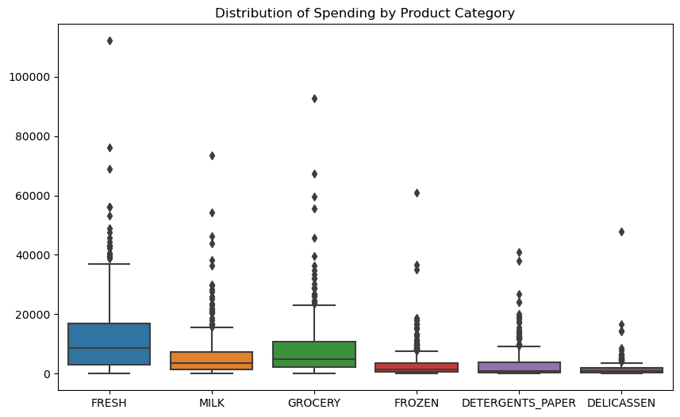

```python
# Corrected boxplot code
plt.figure(figsize=(10, 6))
sns.boxplot(data=data[['FRESH', 'MILK', 'GROCERY', 'FROZEN', 'DETERGENTS_PAPER', 'DELICASSEN']])
plt.title('Distribution of Spending by Product Category')
plt.show()
```

### 7.2.0 Channel and Region Distribution

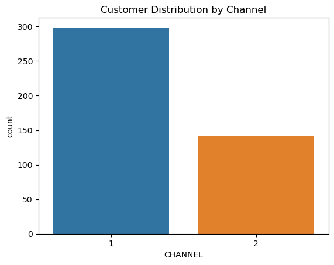

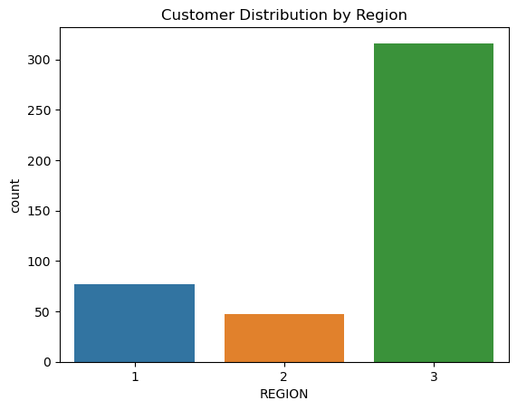

```python
# Channel distribution
sns.countplot(data=data, x='CHANNEL')
plt.title('Customer Distribution by Channel')
plt.show()

# Region distribution
sns.countplot(data=data, x='REGION')
plt.title('Customer Distribution by Region')
plt.show()
```

### 8.0.0 Correlation Analysis

Analyze the relationship between different product categories to see if there is any correlation between spending on different products.

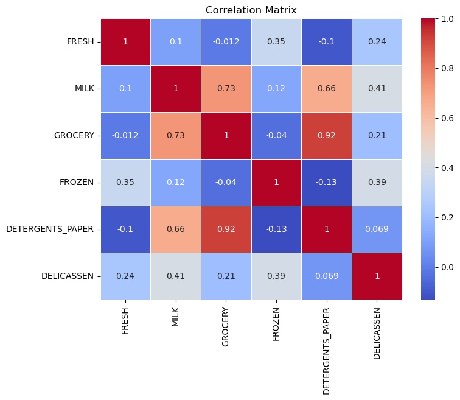

```python
# Compute the correlation matrix
corr = data[['FRESH', 'MILK', 'GROCERY', 'FROZEN', 'DETERGENTS_PAPER', 'DELICASSEN']].corr()

# Plot a heatmap of the correlation matrix
plt.figure(figsize=(8, 6))
sns.heatmap(corr, annot=True, cmap='coolwarm', linewidths=0.5)
plt.title('Correlation Matrix')
plt.show()
```

### 9.0.0 Clustering (Optional)

For more advanced analysis, you could perform clustering to segment customers based on their spending behavior.

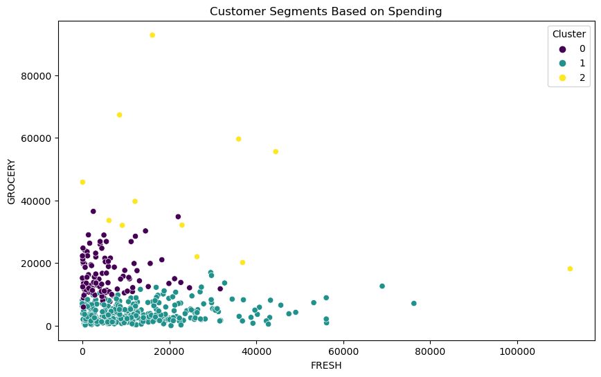

```python
from sklearn.preprocessing import StandardScaler
from sklearn.cluster import KMeans
import matplotlib.pyplot as plt
import seaborn as sns

# Standardize the data
scaler = StandardScaler()
data_scaled = scaler.fit_transform(data[['FRESH', 'MILK', 'GROCERY', 'FROZEN', 'DETERGENTS_PAPER', 'DELICASSEN']])

# Apply KMeans clustering
kmeans = KMeans(n_clusters=3, random_state=0)
data['Cluster'] = kmeans.fit_predict(data_scaled)

# Visualize the clusters
plt.figure(figsize=(10, 6))
sns.scatterplot(data=data, x='FRESH', y='GROCERY', hue='Cluster', palette='viridis')
plt.title('Customer Segments Based on Spending')
plt.show()
```

### Conclusion and Reporting

This process will allow you to perform data analytics comprehensively on your wholesale customer data using Jupyter Notebook.